# Estudios de Informática, Multimedia y Telecomunicaciones

## 4.2 Ejercicio 2.1:

En este ejercicio seguiréis los pasos del ciclo de vida de un proyecto de minería de datos para el caso de un algoritmo de generación de reglas de asociación. Lo haréis con el fichero Lastfm.csv que encontraréis adjunto. Este fichero contiene un conjunto de registros. Estos registros son el histórico de las canciones que ha escuchado un usuario (user) en un portal Web de música. “artist” es el nombre del grupo que ha escuchado, sex y country corresponden a variables que describen al usuario.

### 4.2.1 Respuesta 2.1:

$\color{red}{\text{10% Se realiza un resumen de los datos incluidos en la base de datos}}$

Este ejercicio consiste en extraer las reglas de asociación en los datos contenidos en el dataset lastfm.csv. El alcance solo será extraer estar reglas respecto al campo artist. Pero antes vamos a cargar el dataset y resumir la información contenida en el archivo.

```r
library(arules)
library(dplyr)
library(plyr)

#Leemos el archivo CSV original
historico_artist <- read.csv("lastfm.csv", sep=",", encoding = "UTF-8", stringsAsFactors = TRUE)

summary(historico_artist)
```

```
##       user                         artist       sex
##  Min.   :    1   radiohead            :  2704   f: 78132
##  1st Qu.: 4935   the beatles          :  2668   m:211823
##  Median : 9838   coldplay             :  2378
##  Mean   : 9852   red hot chili peppers:  1786
##  3rd Qu.:14769   muse                 :  1711
##  Max.   :19718   metallica            :  1670
##                  (Other)              :277038
##            country
##  United States : 59558
##  United Kingdom: 27638
##  Germany       : 24251
##  Poland        : 17111
##  Sweden        : 12379
##  Brazil        : 11922
##  (Other)       :137096
```

El archivo contiene 4 atributos: user, artist, sex y country. Para efectos del ejercicio solo vamos a trabajar con las variables user y artist con las cuales formaremos las reglas de asociación.

Primero, vamos a proceder a preparar los datos

$\color{red}{\text{15% Se preparan los datos de forma correcta}}$

```r
# Creamos un array con los atributos user y artist, para poder agruparlos
array_user_artist <- historico_artist[, 1:2]

str(array_user_artist)
```

```
## 'data.frame':    289955 obs. of  2 variables:
##  $ user  : int  1 1 1 1 1 1 1 1 1 1 ...
##  $ artist: Factor w/ 1004 levels "...and you will know us by the trail of dead",..: 715 851 374 281 513 751 289 430 300 896 ...
```

```r
# Procedemos a transformar en formato transacciones
lista_artist <- ddply(array_user_artist, c("user"), function(df1)paste(df1$artist, collapse = ","))

# Eliminamos la columna user, por ya no ser necesaria
lista_artist$user <- NULL

# Dividimos la cadena en elementos. Aplicamos parametros para caracteres especiales
items <- strsplit(as.character(lista_artist$V1), ",", perl = TRUE, useBytes = FALSE)

# Obtenemos las transacciones
transacciones <- as(items, "transactions")

#Inspeccionamos las transacciones
inspect(head(transacciones, 5))
```

```
##     items
## [1] {dropkick murphys,
##      edguy,
##      eluveitie,
##      goldfrapp,
##      guano apes,
##      jack johnson,
##      john mayer,
##      judas priest,
##      le tigre,
##      red hot chili peppers,
##      rob zombie,
##      schandmaul,
##      the black dahlia murder,
##      the killers,
##      the rolling stones,
##      the who}
## [2] {aesop rock,
##      air,
##      amon tobin,
##      animal collective,
##      aphex twin,
##      arcade fire,
##      atmosphere,
##      autechre,
##      beastie boys,
##      boards of canada,
##      broken social scene,
##      cocorosie,
##      devendra banhart,
##      four tet,
##      goldfrapp,
##      joanna newsom,
##      m83,
##      massive attack,
##      max richter,
##      mf doom,
##      neutral milk hotel,
##      pavement,
##      plaid,
```

[output cut: 52 more lines]

```
##      lily allen,
##      manu chao,
##      metallica,
##      muse,
##      pearl jam,
##      pink floyd,
##      queen,
##      sigur rós,
##      snow patrol,
##      stevie wonder,
##      tenacious d,
##      the streets,
##      thievery corporation,
##      type o negative,
##      u2}
```

En el siguiente plot podemos ver que los 20 artistas más escuchados por los usuarios que intervienen en el dataset original son:

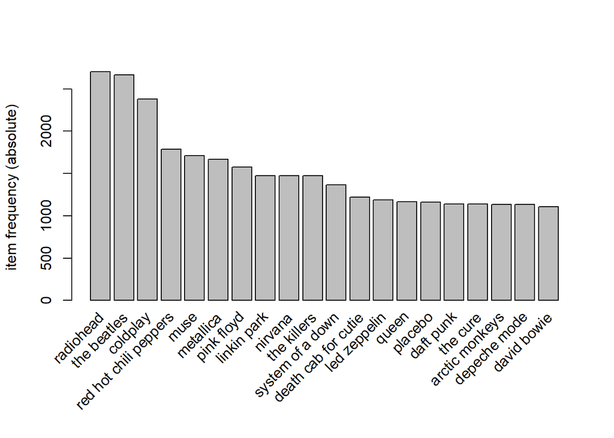

```r
itemFrequencyPlot(transacciones, topN=20, type="absolute")
```

Ya se tiene una lista de transacciones en base a los artistas. Ahora procedamos a aplicar el algoritmo de reglas de asociación. Para ello vamos a usar la función apriori de la librería **arules**

$\color{red}{\text{10% Se aplica el algoritmo de reglas de asociación}}$ $\color{red}{\text{20% Se realizan diferentes pruebas variando algunos parámetros}}$

Para iniciar este punto de la rúbrica es necesario recordar que:

> NOTA: Para considerar una regla interesante, debe ser lo suficientemente frecuente y fuerte (esto es, tener bastante soporte y confianza).

> NOTA: El soporte indica cuantas veces se han encontrado las reglas {lsh => rhs} en el dataset, cuanto más alto mejor. La confianza habla de la probabilidad de que {rhs} se de en función de {lhs}.

Vamos a pruebas realizar una primera prueba general

Realizamos la primera prueba para un valor de soporte de 0.01 y confianza de 0.5

```r
# Obtenemos las reglas
reglas <- apriori(transacciones,  parameter = list(supp = 0.01, conf = 0.50))
```

```
## Apriori
##
## Parameter specification:
##  confidence minval smax arem  aval originalSupport maxtime support minlen
##         0.5    0.1    1 none FALSE            TRUE       5    0.01      1
##  maxlen target  ext
##      10  rules TRUE
##
## Algorithmic control:
##  filter tree heap memopt load sort verbose
##     0.1 TRUE TRUE  FALSE TRUE    2    TRUE
##
## Absolute minimum support count: 150
##
## set item appearances ...[0 item(s)] done [0.00s].
## set transactions ...[1004 item(s), 15000 transaction(s)] done [0.07s].
## sorting and recoding items ... [655 item(s)] done [0.01s].
## creating transaction tree ... done [0.01s].
## checking subsets of size 1 2 3 4 done [0.02s].
## writing ... [50 rule(s)] done [0.00s].
## creating S4 object  ... done [0.00s].
```

```r
# Ordenamos las reglas por su confianza
reglas <- sort(reglas, by="confidence", decreasing=TRUE)

# Vemos la estructura de las reglas
str(reglas)
```

```
## Formal class 'rules' [package "arules"] with 4 slots
##   ..@ lhs    :Formal class 'itemMatrix' [package "arules"] with 3 slots
##   .. .. ..@ data       :Formal class 'ngCMatrix' [package "Matrix"] with 5 slots
##   .. .. .. .. ..@ i       : int [1:85] 641 895 772 848 482 704 789 203 926 848 ...
##   .. .. .. .. ..@ p       : int [1:51] 0 2 4 5 7 9 11 13 15 17 ...
##   .. .. .. .. ..@ Dim     : int [1:2] 1004 50
##   .. .. .. .. ..@ Dimnames:List of 2
##   .. .. .. .. .. ..$ : NULL
##   .. .. .. .. .. ..$ : NULL
##   .. .. .. .. ..@ factors : list()
##   .. .. ..@ itemInfo   :'data.frame':    1004 obs. of  1 variable:
##   .. .. .. ..$ labels: chr [1:1004] "...and you will know us by the trail of dead" "[unknown]" "2pac" "3 doors down" ...
##   .. .. ..@ itemsetInfo:'data.frame':    0 obs. of  0 variables
##   ..@ rhs    :Formal class 'itemMatrix' [package "arules"] with 3 slots
##   .. .. ..@ data       :Formal class 'ngCMatrix' [package "Matrix"] with 5 slots
##   .. .. .. .. ..@ i       : int [1:50] 203 704 203 203 704 704 848 684 203 848 ...
##   .. .. .. .. ..@ p       : int [1:51] 0 1 2 3 4 5 6 7 8 9 ...
##   .. .. .. .. ..@ Dim     : int [1:2] 1004 50
##   .. .. .. .. ..@ Dimnames:List of 2
##   .. .. .. .. .. ..$ : NULL
##   .. .. .. .. .. ..$ : NULL
##   .. .. .. .. ..@ factors : list()
##   .. .. ..@ itemInfo   :'data.frame':    1004 obs. of  1 variable:
##   .. .. .. ..$ labels: chr [1:1004] "...and you will know us by the trail of dead" "[unknown]" "2pac" "3 doors down" ...
##   .. .. ..@ itemsetInfo:'data.frame':    0 obs. of  0 variables
##   ..@ quality:'data.frame':  50 obs. of  5 variables:
##   .. ..$ support   : num [1:50] 0.0111 0.0105 0.0223 0.0101 0.0109 ...
##   .. ..$ confidence: num [1:50] 0.663 0.643 0.637 0.634 0.628 ...
##   .. ..$ coverage  : num [1:50] 0.0168 0.0163 0.0349 0.0159 0.0174 ...
##   .. ..$ lift      : num [1:50] 4.18 3.57 4.02 4 3.49 ...
##   .. ..$ count     : int [1:50] 167 157 334 151 164 172 155 160 156 172 ...
##   ..@ info   :List of 4
##   .. ..$ data         : symbol transacciones
##   .. ..$ ntransactions: int 15000
##   .. ..$ support      : num 0.01
##   .. ..$ confidence   : num 0.5
```

```r
# Desplegamos las reglas en la pantalla
inspect(reglas)
```

```
##      lhs                                    rhs            support
## [1]  {oasis,the killers}                 => {coldplay}     0.01113333
## [2]  {sigur rós,the beatles}             => {radiohead}    0.01046667
## [3]  {keane}                             => {coldplay}     0.02226667
## [4]  {radiohead,snow patrol}             => {coldplay}     0.01006667
## [5]  {coldplay,the smashing pumpkins}    => {radiohead}    0.01093333
## [6]  {the beatles,the smashing pumpkins} => {radiohead}    0.01146667
## [7]  {bob dylan,pink floyd}              => {the beatles}  0.01033333
## [8]  {led zeppelin,the doors}            => {pink floyd}   0.01066667
## [9]  {snow patrol,the killers}           => {coldplay}     0.01040000
## [10] {bob dylan,the rolling stones}      => {the beatles}  0.01146667
## [11] {beck,the beatles}                  => {radiohead}    0.01300000
## [12] {death cab for cutie,the killers}   => {coldplay}     0.01086667
## [13] {oasis,radiohead}                   => {coldplay}     0.01273333
## [14] {coldplay,sigur rós}                => {radiohead}    0.01206667
```

[output cut: 87 more lines]

```r
# Revisamos si existen reglas duplicadas
duplicated(reglas)
```

```
##  [1] FALSE FALSE FALSE FALSE FALSE FALSE FALSE FALSE FALSE FALSE FALSE FALSE
## [13] FALSE FALSE FALSE FALSE FALSE FALSE FALSE FALSE FALSE FALSE FALSE FALSE
## [25] FALSE FALSE FALSE FALSE FALSE FALSE FALSE FALSE FALSE FALSE FALSE FALSE
## [37] FALSE FALSE FALSE FALSE FALSE FALSE FALSE FALSE FALSE FALSE FALSE FALSE
## [49] FALSE FALSE
```

```r
# Verificamos si hay reglas redundantes
reglas_redundantes <- is.redundant(reglas)
```

Vamos a ordenarlas ahora por su valor de soporte, de mayor a menor, para conocer cuales reglas superan el valor de soporte mínimo (*min_sop*) y puedan considerarse **grandes grupos** y sean consideras para la siguiente prueba.

```r
# Ordenamos las reglas por su valor de soporte
reglas <- sort(reglas, by="support", decreasing=TRUE)

# Vemos la estructura de las reglas
str(reglas)
```

```
## Formal class 'rules' [package "arules"] with 4 slots
##   ..@ lhs    :Formal class 'itemMatrix' [package "arules"] with 3 slots
##   .. .. ..@ data       :Formal class 'ngCMatrix' [package "Matrix"] with 5 slots
##   .. .. .. .. ..@ i       : int [1:85] 102 789 482 131 564 776 605 895 151 704 ...
##   .. .. .. .. ..@ p       : int [1:51] 0 1 2 3 4 5 6 8 9 11 ...
##   .. .. .. .. ..@ Dim     : int [1:2] 1004 50
##   .. .. .. .. ..@ Dimnames:List of 2
##   .. .. .. .. .. ..$ : NULL
##   .. .. .. .. .. ..$ : NULL
##   .. .. .. .. ..@ factors : list()
##   .. .. ..@ itemInfo   :'data.frame':    1004 obs. of  1 variable:
##   .. .. .. ..$ labels: chr [1:1004] "...and you will know us by the trail of dead" "[unknown]" "2pac" "3 doors down" ...
##   .. .. ..@ itemsetInfo:'data.frame':    0 obs. of  0 variables
##   ..@ rhs    :Formal class 'itemMatrix' [package "arules"] with 3 slots
##   .. .. ..@ data       :Formal class 'ngCMatrix' [package "Matrix"] with 5 slots
##   .. .. .. .. ..@ i       : int [1:50] 704 203 203 704 567 848 203 704 203 848 ...
##   .. .. .. .. ..@ p       : int [1:51] 0 1 2 3 4 5 6 7 8 9 ...
##   .. .. .. .. ..@ Dim     : int [1:2] 1004 50
##   .. .. .. .. ..@ Dimnames:List of 2
##   .. .. .. .. .. ..$ : NULL
##   .. .. .. .. .. ..$ : NULL
##   .. .. .. .. ..@ factors : list()
##   .. .. ..@ itemInfo   :'data.frame':    1004 obs. of  1 variable:
##   .. .. .. ..$ labels: chr [1:1004] "...and you will know us by the trail of dead" "[unknown]" "2pac" "3 doors down" ...
##   .. .. ..@ itemsetInfo:'data.frame':    0 obs. of  0 variables
##   ..@ quality:'data.frame':  50 obs. of  5 variables:
##   .. ..$ support   : num [1:50] 0.0293 0.0265 0.0223 0.0175 0.0163 ...
##   .. ..$ confidence: num [1:50] 0.509 0.525 0.637 0.523 0.528 ...
##   .. ..$ coverage  : num [1:50] 0.0575 0.0504 0.0349 0.0335 0.0308 ...
##   .. ..$ lift      : num [1:50] 2.83 3.31 4.02 2.9 4.74 ...
##   .. ..$ count     : int [1:50] 439 397 334 263 244 231 227 226 226 209 ...
##   ..@ info   :List of 4
##   .. ..$ data         : symbol transacciones
##   .. ..$ ntransactions: int 15000
##   .. ..$ support      : num 0.01
##   .. ..$ confidence   : num 0.5
```

```r
# Desplegamos las reglas en la pantalla
inspect(reglas)
```

```
##      lhs                                    rhs            support
## [1]  {beck}                              => {radiohead}    0.02926667
## [2]  {snow patrol}                       => {coldplay}     0.02646667
## [3]  {keane}                             => {coldplay}     0.02226667
## [4]  {blur}                              => {radiohead}    0.01753333
## [5]  {megadeth}                          => {metallica}    0.01626667
## [6]  {simon & garfunkel}                 => {the beatles}  0.01540000
## [7]  {muse,the killers}                  => {coldplay}     0.01513333
## [8]  {broken social scene}               => {radiohead}    0.01506667
## [9]  {radiohead,the killers}             => {coldplay}     0.01506667
## [10] {david bowie,radiohead}             => {the beatles}  0.01393333
## [11] {bob dylan,radiohead}               => {the beatles}  0.01386667
## [12] {muse,the beatles}                  => {radiohead}    0.01380000
## [13] {travis}                            => {coldplay}     0.01373333
## [14] {placebo,radiohead}                 => {muse}         0.01366667
```

[output cut: 87 more lines]

Al redondear los valores de confianza a 3 decimales, se obtiene que 39 reglas sobrepasan el valor de soporte mínimo (*min_sop*) de confianza.

Ahora vamos a realizar una segunda prueba, para un valor de soporte de 0.011 y confianza de 0.55

```r
# Obtenemos las reglas
reglas <- apriori(transacciones,  parameter = list(supp = 0.011, conf = 0.55))
```

```
## Apriori
##
## Parameter specification:
##  confidence minval smax arem  aval originalSupport maxtime support minlen
##        0.55    0.1    1 none FALSE            TRUE       5   0.011      1
##  maxlen target  ext
##      10  rules TRUE
##
## Algorithmic control:
##  filter tree heap memopt load sort verbose
##     0.1 TRUE TRUE  FALSE TRUE    2    TRUE
##
## Absolute minimum support count: 165
##
## set item appearances ...[0 item(s)] done [0.00s].
## set transactions ...[1004 item(s), 15000 transaction(s)] done [0.08s].
## sorting and recoding items ... [595 item(s)] done [0.00s].
## creating transaction tree ... done [0.01s].
## checking subsets of size 1 2 3 4 done [0.02s].
## writing ... [9 rule(s)] done [0.00s].
## creating S4 object  ... done [0.00s].
```

```r
# Ordenamos las reglas por su valor de soporte
reglas <- sort(reglas, by="support", decreasing=TRUE)

# Vemos la estructura de las reglas
str(reglas)
```

```
## Formal class 'rules' [package "arules"] with 4 slots
##   ..@ lhs    :Formal class 'itemMatrix' [package "arules"] with 3 slots
##   .. .. ..@ data       :Formal class 'ngCMatrix' [package "Matrix"] with 5 slots
##   .. .. .. .. ..@ i       : int [1:16] 482 133 704 969 102 848 641 704 203 772 ...
##   .. .. .. .. ..@ p       : int [1:10] 0 1 3 4 6 8 10 12 14 16
##   .. .. .. .. ..@ Dim     : int [1:2] 1004 9
##   .. .. .. .. ..@ Dimnames:List of 2
##   .. .. .. .. .. ..$ : NULL
##   .. .. .. .. .. ..$ : NULL
##   .. .. .. .. ..@ factors : list()
##   .. .. ..@ itemInfo   :'data.frame':    1004 obs. of  1 variable:
##   .. .. .. ..$ labels: chr [1:1004] "...and you will know us by the trail of dead" "[unknown]" "2pac" "3 doors down" ...
##   .. .. ..@ itemsetInfo:'data.frame':    0 obs. of  0 variables
##   ..@ rhs    :Formal class 'itemMatrix' [package "arules"] with 3 slots
##   .. .. ..@ data       :Formal class 'ngCMatrix' [package "Matrix"] with 5 slots
##   .. .. .. .. ..@ i       : int [1:9] 203 848 203 704 203 704 848 704 203
##   .. .. .. .. ..@ p       : int [1:10] 0 1 2 3 4 5 6 7 8 9
##   .. .. .. .. ..@ Dim     : int [1:2] 1004 9
##   .. .. .. .. ..@ Dimnames:List of 2
##   .. .. .. .. .. ..$ : NULL
##   .. .. .. .. .. ..$ : NULL
##   .. .. .. .. ..@ factors : list()
##   .. .. ..@ itemInfo   :'data.frame':    1004 obs. of  1 variable:
##   .. .. .. ..$ labels: chr [1:1004] "...and you will know us by the trail of dead" "[unknown]" "2pac" "3 doors down" ...
##   .. .. ..@ itemsetInfo:'data.frame':    0 obs. of  0 variables
##   ..@ quality:'data.frame':  9 obs. of  5 variables:
##   .. ..$ support   : num [1:9] 0.0223 0.0139 0.0137 0.013 0.0127 ...
##   .. ..$ confidence: num [1:9] 0.637 0.573 0.563 0.591 0.588 ...
##   .. ..$ coverage  : num [1:9] 0.0349 0.0242 0.0244 0.022 0.0217 ...
##   .. ..$ lift      : num [1:9] 4.02 3.22 3.55 3.28 3.71 ...
##   .. ..$ count     : int [1:9] 334 208 206 195 191 181 172 172 167
##   ..@ info   :List of 4
##   .. ..$ data         : symbol transacciones
##   .. ..$ ntransactions: int 15000
##   .. ..$ support      : num 0.011
##   .. ..$ confidence   : num 0.55
```

```r
# Desplegamos las reglas en la pantalla
inspect(reglas)
```

```
##     lhs                                    rhs           support    confidence
## [1] {keane}                             => {coldplay}    0.02226667 0.6374046
## [2] {bob dylan,radiohead}               => {the beatles} 0.01386667 0.5730028
## [3] {travis}                            => {coldplay}    0.01373333 0.5628415
## [4] {beck,the beatles}                  => {radiohead}   0.01300000 0.5909091
## [5] {oasis,radiohead}                   => {coldplay}    0.01273333 0.5876923
## [6] {coldplay,sigur rós}                => {radiohead}   0.01206667 0.5801282
## [7] {bob dylan,the rolling stones}      => {the beatles} 0.01146667 0.5910653
## [8] {the beatles,the smashing pumpkins} => {radiohead}   0.01146667 0.6209386
## [9] {oasis,the killers}                 => {coldplay}    0.01113333 0.6626984
##     coverage   lift     count
## [1] 0.03493333 4.020634 334
## [2] 0.02420000 3.221530 208
## [3] 0.02440000 3.550304 206
## [4] 0.02200000 3.277972 195
## [5] 0.02166667 3.707058 191
## [6] 0.02080000 3.218167 181
## [7] 0.01940000 3.323081 172
## [8] 0.01846667 3.444556 172
## [9] 0.01680000 4.180183 167
```

$\color{red}{\text{35% Se explican las conclusiones que se obtienen}}$

$\color{red}{\text{10% Se presenta el código y es fácilmente reproducible}}$

# 5 Bibliografía

[1] Dataset for estimation of obesity levels based on eating habits and physical condition in individuals from Colombia, Peru and Mexico. Alojado en https://doi.org/10.1016/j.dib.2019.104344

[2] Clustering y heatmaps: aprendizaje no supervisado. Alojado en https://www.cienciadedatos.net/documentos/37_clustering_y_heatmaps#K-medoids_clustering_(PAM)

[3] Algoritmo Apriori, https://rociochavezml.com/algoritmo-apriori-en-r/, Rocio Chavez

# 6 Rúbrica

## 6.1 Ejercicio 1.1

- 15%. Se explican los campos de la base de datos, preparación y análisis de datos
- 10%. Se aplica el algoritmo de agrupamiento de forma correcta.
- 25%. Se prueban con diferentes valores de k.
- 10%. Se obtiene una medida de lo bueno que es el agrupamiento.
- 10%. Se ponen nombres a las asociaciones.
- 20%. Se describen e interpretan los diferentes clústers obtenidos.
- 10%. Se presenta el código y es fácilmente reproducible.

## 6.2 Ejercicio 1.2

- 25%. Se prueba un algoritmo diferente al kmeans.
- 25%. Se prueba otro algoritmo diferente al kmeans.
- 40%. Se comparan los resultados del kmeans y los otros dos métodos probados en este ejercicio.
- 10%. Se presenta el código y es fácilmente reproducible.

## 6.3 Ejercicio 2.1

- 10%. Se realiza un resumen de los datos incluidos en la base de datos.
- 15%. Se preparan los datos de forma correcta.
- 10%. Se aplica el algoritmo de reglas de asociación.
- 20%. Se realizan diferentes pruebas variando algunos parámetros.
- 35%. Se explican las conclusiones que se obtienen.
- 10%. Se presenta el código y es fácilmente reproducible.